# Day3_sec_ds_lv3_prob2_prob-Copy2

## 단계 2-5

prob2_train으로 [단계 2-2]에서 도출된 변수들로 PCA 모델을 만들고

분산 설명률이 높은 순으로 누적 분산 설명률이 0.8을 넘기는 최소의 컴포넌트를 prob2_train에 추가 한다.

동일한 PCA 모델로 prob2_test를 변환하여 같은 수의 컴포넌트를 prob2_test에 추가 한다.

**함수가이드**

sklearn.decomposition.PCA (입력의 순서는 cont 뒤의 번호가 낮은 것에서 높은 것 순으로 한다, random_state=123)

문제 지시사항 외 Default 값 사용

```python
from sklearn.decomposition import PCA

# 분산 설명률이 높은 순으로 누적 분산 설명률이 0.8
pca = PCA(n_components = 0.8, random_state=123)

pca.fit(df_prob2_train[X_corr])
```

```
PCA(copy=True, iterated_power='auto', n_components=0.8, random_state=123,
    svd_solver='auto', tol=0.0, whiten=False)
```

```python
print('pca.n_components_ = ', pca.n_components_)
```

```
pca.n_components_ =  3
```

```python
X_comp = ['pca_{}'.format(i) for i in range(pca.n_components_)]
print('X_comp = ', X_comp)

df_prob2_train[X_comp] = pd.DataFrame(pca.transform(df_prob2_train[X_corr]), index=df_prob2_train.index, columns=X_comp)
df_prob2_test[X_comp] = pd.DataFrame(pca.transform(df_prob2_test[X_corr]), index=df_prob2_test.index, columns=X_comp)
```

```
X_comp =  ['pca_0', 'pca_1', 'pca_2']
```

```python
df_prob2_train[X_comp]
```

| id | pca_0 | pca_1 | pca_2 |
| --- | --- | --- | --- |
| 487693 | -0.363381 | 0.018541 | -0.051800 |
| 307175 | -0.103216 | 0.294394 | -0.096653 |
| 493409 | 0.853154 | 0.047363 | 0.104571 |
| 414858 | -0.079167 | 0.021580 | -0.084363 |
| 408161 | 0.149872 | -0.073583 | 0.197499 |
| ... | ... | ... | ... |
| 486483 | 0.520503 | -0.250642 | 0.132757 |
| 397343 | -0.536040 | -0.013147 | 0.156720 |
| 119442 | 0.270999 | -0.172300 | -0.083993 |
| 127964 | -0.345073 | 0.095621 | -0.046980 |
| 128591 | 0.103191 | -0.117542 | -0.011144 |

192000 rows × 3 columns

```python
df_prob2_test[X_comp]
```

| id | pca_0 | pca_1 | pca_2 |
| --- | --- | --- | --- |
| 309145 | 0.891113 | 0.078173 | 0.042182 |
| 368647 | -0.402723 | -0.154452 | 0.026537 |
| 487072 | -0.216491 | 0.056313 | 0.024912 |
| 490811 | -0.226155 | 0.157114 | -0.021635 |
| 484687 | -0.018692 | 0.390843 | 0.329713 |
| ... | ... | ... | ... |
| 11528 | -0.302192 | 0.092255 | -0.002482 |
| 484506 | -0.353851 | 0.035517 | -0.045551 |
| 465250 | 0.183479 | -0.179650 | -0.002625 |
| 361168 | 0.518040 | 0.007619 | 0.107655 |
| 268321 | 0.157793 | -0.196783 | 0.075800 |

48000 rows × 3 columns

```python
# 단계 2-5 설명

'''
코드는 PCA (주성분 분석)를 사용하여 원래 변수들의 차원을 축소하고,
훈련 데이터와 테스트 데이터에 대해 주성분을 계산하여 데이터프레임에 추가하는 작업을 수행합니다.

### 1. 데이터 분할 및 복사
- `train_test_split`을 사용하여 `df_prob2` 데이터를 훈련 세트(80%)와 테스트 세트(20%)로 분할합니다.
- `df_prob2_train`과 `df_prob2_test`을 각각 복사합니다.
    이는 원본 데이터프레임을 보호하고 이후의 변환 작업이 독립적으로 수행되도록 하기 위함입니다.

### 2. PCA 객체 생성 및 학습
- `PCA` 객체를 생성합니다.
  - `n_components=0.8`: 누적 분산 설명률이 80%가 될 때까지 주성분을 선택합니다.
      즉, 데이터의 분산을 80% 설명할 수 있는 주성분의 수를 자동으로 결정합니다.
  - `random_state=123`: 랜덤 상태를 설정하여 결과가 재현 가능하도록 합니다.

- `pca.fit`을 사용하여 `df_prob2_train`의 `X_corr` 열에 해당하는 데이터에 대해 PCA를 학습시킵니다.
    `X_corr`은 이전에 식별된 가장 큰 클러스터의 변수들을 포함합니다.

### 3. 주성분 변수 생성 및 훈련 데이터 변환
- `pca.n_components_`는 누적 분산 설명률이 80%에 도달할 때까지 선택된 주성분의 수를 나타냅니다.
- 주성분 변수 이름을 생성합니다. 예를 들어, `pca_0`, `pca_1` 등으로 이름을 지정합니다.

- `pca.transform`을 사용하여 `df_prob2_train`의 `X_corr` 열에 해당하는 데이터를 주성분 공간으로 변환합니다.
- 변환된 주성분 데이터를 데이터프레임으로 변환하고, `X_comp`를 열 이름으로 사용하며, 원래의 인덱스를 유지합니다.
- 변환된 주성분 데이터를 `df_prob2_train` 데이터프레임에 추가합니다.

### 4. 테스트 데이터 변환
- `pca.transform`을 사용하여 `df_prob2_test`의 `X_corr` 열에 해당하는 데이터를 주성분 공간으로 변환합니다.
- 변환된 주성분 데이터를 데이터프레임으로 변환하고, `X_comp`를 열 이름으로 사용하며, 원래의 인덱스를 유지합니다.
- 변환된 주성분 데이터를 `df_prob2_test` 데이터프레임에 추가합니다.

### 전체 코드 동작 요약
1. 데이터 분할: 원본 데이터프레임 `df_prob2`를 훈련 세트와 테스트 세트로 분할합니다.
2. PCA 학습: 훈련 세트의 특정 변수들(`X_corr`)에 대해 PCA를 수행하여 누적 분산 설명률이 80%가 될 때까지 주성분을 선택합니다.
3. 주성분 변수 생성 및 추가:
   - 훈련 세트와 테스트 세트 각각에 대해 선택된 주성분으로 데이터를 변환하고, 이를 데이터프레임에 추가합니다.
   - 결과적으로, `df_prob2_train`과 `df_prob2_test`는 원래 변수들 외에 주성분 변수들도 포함하게 됩니다.

이 과정을 통해 데이터의 차원을 축소하고, 중요한 정보를 유지하면서 데이터의 구조를 단순화할 수 있습니다.
이는 모델 학습 시 과적합을 줄이고 계산 효율성을 높이는 데 도움이 됩니다.
'''
print('')
```

## 단계 2-6

prob2_train에서 target을 선형회귀모델로 학습하고

prob2_test를 다음 성능 지표로 평가한 값을 A라고 한다.

입력변수: cont0 ~ 13, cat0 ~ 9 원핫-인코딩 후 나온

파생 변수 (변수명, 범주명 알파벳 순서)

대상변수: target

성능지표: $MSE(Y, \hat{Y}) = \frac{1}{n}\sum^{n}_{i=1}(y_i-\hat{y_i})^2$

Hint] 학습데이터의 형태는 (192,000, 43) 이다.

**함수가이드**

sklearn.linear_model.LinearRegression

문제 지시사항 외 Default 값 사용

```python
'''
코드는 `LinearRegression` 모델을 사용하여 예측을 수행하고,
훈련 데이터와 테스트 데이터에 대해 평균 제곱 오차(MSE)를 계산하는 작업을 수행합니다.

### 1. 독립 변수 리스트 생성
- `cont_cols`: 연속형 변수들의 리스트입니다.
- `dum_cols.tolist()`: 범주형 변수를 원-핫 인코딩한 결과로 생성된 더미 변수들의 리스트입니다.
- `X_lr`는 이 두 리스트를 합친 것으로, 회귀 모델에 사용할 모든 독립 변수들의 리스트입니다.

### 2. 선형 회귀 모델 생성 및 학습
- `LinearRegression` 객체를 생성합니다.
- `reg_lr.fit`을 사용하여 `df_prob2_train` 데이터프레임의 독립 변수(`X_lr`)와
    종속 변수(`target`)를 사용하여 회귀 모델을 학습시킵니다.

### 3. 테스트 데이터에 대한 예측 및 MSE 계산
- `reg_lr.predict`을 사용하여 `df_prob2_test` 데이터프레임의 독립 변수(`X_lr`)를 기반으로 `target` 값을 예측합니다.
- `mean_squared_error`를 사용하여 실제 `target` 값과 예측된 `target` 값 간의 평균 제곱 오차(MSE)를 계산합니다.
- 이 값은 테스트 데이터에 대한 예측 성능을 나타내며, 변수 `A`에 저장됩니다.

### 4. 훈련 데이터에 대한 예측 및 MSE 계산
- 훈련 데이터에 대해서도 `reg_lr.predict`을 사용하여 독립 변수(`X_lr`)를 기반으로 `target` 값을 예측합니다.
- `mean_squared_error`를 사용하여 훈련 데이터의 실제 `target` 값과 예측된 `target` 값 간의 평균 제곱 오차(MSE)를 계산합니다.
- 결과는 튜플 형태로 반환됩니다. 첫 번째 값은 테스트 데이터의 MSE(`A`), 두 번째 값은 훈련 데이터의 MSE입니다.

### 전체 코드 동작 요약
1. 독립 변수 리스트 생성: 모델에 사용할 연속형 변수들과 원-핫 인코딩된 범주형 변수들을 합쳐서 `X_lr` 리스트를 생성합니다.
2. 선형 회귀 모델 학습: `df_prob2_train` 데이터프레임을 사용하여 `LinearRegression` 모델을 학습시킵니다.
3. 테스트 데이터 예측 및 MSE 계산: 테스트 데이터에 대해 예측을 수행하고, 평균 제곱 오차를 계산하여 `A` 변수에 저장합니다.
4. 훈련 데이터 예측 및 MSE 계산: 훈련 데이터에 대해 예측을 수행하고, 평균 제곱 오차를 계산합니다.
5. 결과 반환: 테스트 데이터의 MSE와 훈련 데이터의 MSE를 튜플 형태로 반환합니다.

이 과정은 모델의 성능을 평가하는 데 사용됩니다. 테스트 데이터에 대한 MSE는 모델의 일반화 성능을 나타내고,
훈련 데이터에 대한 MSE는 모델이 훈련 데이터에 얼마나 잘 맞는지를 나타냅니다.
이 두 값의 비교를 통해 모델이 과적합(overfitting)되었는지 또는 과소적합(underfitting)되었는지를 판단할 수 있습니다.
'''

from sklearn.linear_model import LinearRegression
from sklearn.metrics import mean_squared_error

X_lr = cont_cols + dum_cols.tolist()
print('X_lr = ', X_lr)

reg_lr = LinearRegression()
reg_lr.fit(df_prob2_train[X_lr], df_prob2_train['target'])

A = mean_squared_error(
    df_prob2_test['target'], reg_lr.predict(df_prob2_test[X_lr])
)
(
    A,
    mean_squared_error(df_prob2_train['target'], reg_lr.predict(df_prob2_train[X_lr]))
)
```

```
X_lr =  ['cont0', 'cont1', 'cont2', 'cont3', 'cont4', 'cont5', 'cont6', 'cont7', 'cont8', 'cont9', 'cont10', 'cont11', 'cont12', 'cont13', 'cat0_B', 'cat1_B', 'cat2_B', 'cat3_C', 'cat3_D', 'cat4_C', 'cat5_B', 'cat5_C', 'cat5_D', 'cat6_B', 'cat6_C', 'cat7_D', 'cat7_E', 'cat7_G', 'cat8_C', 'cat8_D', '…
```

```
(0.7455022756348629, 0.7446868277591954)
```

## 단계 2-7

prob2_train에서 cont0 ~ 13 중에서 PCA에서 사용했던 변수를 제외하고

단계 2-5에서 추가한 PCA 컴포넌트를 포함하여 target로 선형회귀모델을 학습한다.

prob2_test로 동일한 지표로 대한 성능 평가한 값을 B라 한다.

입력변수: cont0 ~ 13중 PCA에 사용한 것을 제외한 나머지 변수,

PCA를 통한 파생 변수를 분산 설명력이 높은 순으로,

cat0 ~ 9까지 원핫-인코딩 후 나온 파생 변수 (변수명, 범주명 알파벳 순서)

대상변수: target

성능지표: $MSE(Y, \hat{Y}) = \frac{1}{n}\sum^{n}_{i=1}(y_i-\hat{y_i})^2$

**함수가이드**

sklearn.linear_model.LinearRegression

문제 지시사항 외 Default 값 사용

```python
'''
코드는 이전 코드와 비슷한 작업을 수행하지만, 사용하는 독립 변수가 다릅니다.
새로운 독립 변수 리스트를 생성하고, 그 리스트를 사용하여 선형 회귀 모델을 학습
및 평가합니다.

### 1. 새로운 독립 변수 리스트 생성
- `cont_cols`: 연속형 변수들의 리스트입니다.
- `X_corr`: PCA에서 사용된 연속형 변수들의 리스트입니다.
- `[i for i in cont_cols if i not in X_corr]`:
    PCA에 사용되지 않은 연속형 변수들을 선택합니다.
- `X_comp`: PCA 변환 후 생성된 주성분 변수들의 리스트입니다.
- `dum_cols.tolist()`: 범주형 변수를 원-핫 인코딩한 결과로 생성된 더미 변수들의 리스트입니다.
- 이 세 리스트를 합쳐서 최종 독립 변수 리스트 `X_lr`를 생성합니다.
    이는 PCA에서 사용되지 않은 연속형 변수들, 주성분 변수들, 그리고 더미 변수들을 포함합니다.

### 2. 선형 회귀 모델 생성 및 학습
reg_lr = LinearRegression()
reg_lr.fit(df_prob2_train[X_lr], df_prob2_train['target'])
- `LinearRegression` 객체를 생성합니다.
- `reg_lr.fit`을 사용하여 `df_prob2_train` 데이터프레임의 독립 변수(`X_lr`)와 종속 변수(`target`)를 사용하여
    회귀 모델을 학습시킵니다.

### 3. 테스트 데이터에 대한 예측 및 MSE 계산
B = mean_squared_error(
    df_prob2_test['target'], reg_lr.predict(df_prob2_test[X_lr])
)
- `reg_lr.predict`을 사용하여 `df_prob2_test` 데이터프레임의 독립 변수(`X_lr`)를 기반으로
    `target` 값을 예측합니다.
- `mean_squared_error`를 사용하여 실제 `target` 값과 예측된 `target` 값 간의 평균 제곱 오차(MSE)를 계산합니다.
- 이 값은 테스트 데이터에 대한 예측 성능을 나타내며, 변수 `B`에 저장됩니다.

### 4. 훈련 데이터에 대한 예측 및 MSE 계산
- 훈련 데이터에 대해서도 `reg_lr.predict`을 사용하여 독립 변수(`X_lr`)를 기반으로 `target` 값을 예측합니다.
- `mean_squared_error`를 사용하여 훈련 데이터의 실제 `target` 값과 예측된 `target` 값 간의
    평균 제곱 오차(MSE)를 계산합니다.
- 결과는 튜플 형태로 반환됩니다. 첫 번째 값은 테스트 데이터의 MSE(`B`), 두 번째 값은 훈련 데이터의 MSE입니다.

### 전체 코드 동작 요약
1. 새로운 독립 변수 리스트 생성: PCA에서 사용되지 않은 연속형 변수들, 주성분 변수들,
    그리고 원-핫 인코딩된 범주형 변수들을 합쳐서 `X_lr` 리스트를 생성합니다.
2. 선형 회귀 모델 학습: `df_prob2_train` 데이터프레임을 사용하여 `LinearRegression` 모델을 학습시킵니다.
3. 테스트 데이터 예측 및 MSE 계산: 테스트 데이터에 대해 예측을 수행하고,
    평균 제곱 오차를 계산하여 `B` 변수에 저장합니다.
4. 훈련 데이터 예측 및 MSE 계산: 훈련 데이터에 대해 예측을 수행하고, 평균 제곱 오차를 계산합니다.
5. 결과 반환: 테스트 데이터의 MSE와 훈련 데이터의 MSE를 튜플 형태로 반환합니다.

이 과정은 모델의 성능을 평가하는 데 사용됩니다. 테스트 데이터에 대한 MSE는 모델의 일반화 성능을 나타내고,
훈련 데이터에 대한 MSE는 모델이 훈련 데이터에 얼마나 잘 맞는지를 나타냅니다.
두 값의 비교를 통해 모델이 과적합(overfitting)되었는지 또는 과소적합(underfitting)되었는지를 판단할 수 있습니다.
'''

from sklearn.linear_model import LinearRegression
from sklearn.metrics import mean_squared_error

X_lr = [i for i in cont_cols if i not in X_corr] + X_comp + dum_cols.tolist()
print('X_lr = ', X_lr)

reg_lr = LinearRegression()
reg_lr.fit(df_prob2_train[X_lr], df_prob2_train['target'])

B = mean_squared_error(df_prob2_test['target'], reg_lr.predict(df_prob2_test[X_lr]))
(
    B,
    mean_squared_error(df_prob2_train['target'], reg_lr.predict(df_prob2_train[X_lr]))
)
```

```
X_lr =  ['cont1', 'cont2', 'cont3', 'cont4', 'cont6', 'cont7', 'cont10', 'cont11', 'cont13', 'pca_0', 'pca_1', 'pca_2', 'cat0_B', 'cat1_B', 'cat2_B', 'cat3_C', 'cat3_D', 'cat4_C', 'cat5_B', 'cat5_C', 'cat5_D', 'cat6_B', 'cat6_C', 'cat7_D', 'cat7_E', 'cat7_G', 'cat8_C', 'cat8_D', 'cat8_E', 'cat8_G', …
```

```
(0.7499049886498875, 0.7487486877700789)
```

```python
A, B, A - B, round(A - B, 3)
```

```
(0.7455022756348629, 0.7499049886498875, -0.004402713015024595, -0.004)
```

A-B 를 소수점 넷째 자리에서 반올림하여 셋째 자리까지 구하라.

**-0.004**

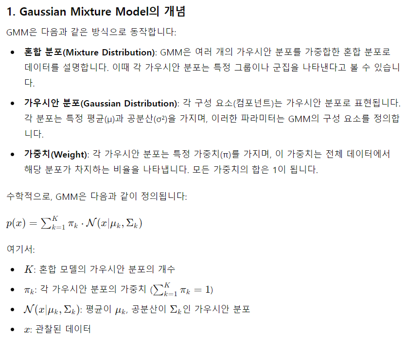

```python
Image('3-6.png')
```

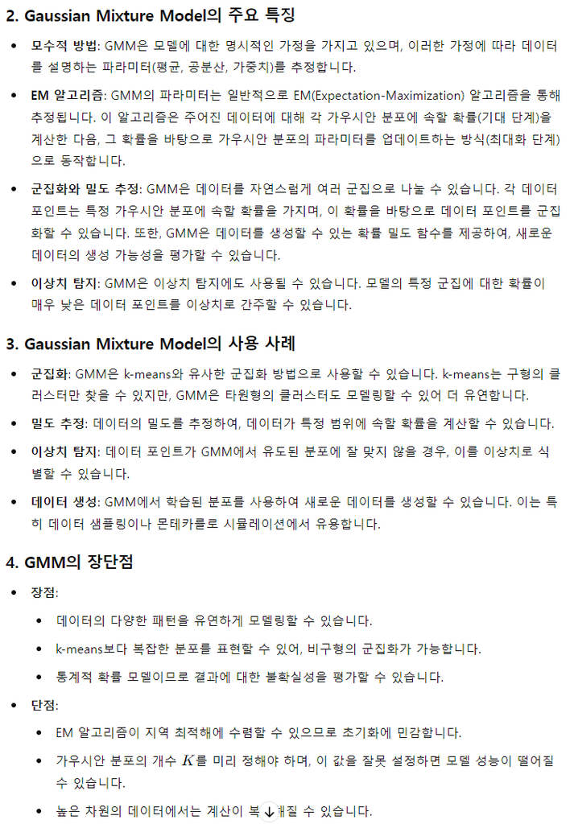

```python
Image('3-7.png')
```